# 政治学方法論 I：課題3の解答例

矢内 勇生

October 16, 2014

## 1. 階乗を計算する関数を作る

Rには`factorial()` という関数が用意されているが、これを使わずに階乗を計算する`myfactorial` という名前の関数を用意する。 以下はあくまで一例であり、答え（コーディングの仕方）が完全に一致する必要なない。

```r
myfactorial <- function(x){ # 階乗を計算する関数を作る
    ## ただし、非負の整数以外は計算しない
    ## 引数：x = 非負の整数
    ## 返り値: out = 階乗の計算結果、数値

    if(x < 0 | x != round(x)){ # 負の数または整数以外は計算しない
        stop(message=paste("x (", x, ") must be non-negative integer",
                             sep=""))
    }else if(x == 0){ # 0の階乗は1
        return(1)
    }else{ # 上の場合以外は実際に計算する
        out <- 1
        for(i in 1:x){
            out = out * i
        }
        return(out)
    }
}
```

この関数は、引数に非負の整数 ($0, 1, 2, \dots$) を与えない限りエラーになる。 関数の中で、以下の3つの場合を分けて処理している。

1. 引数に負の値または整数でない値が与えられた場合
2. 引数に0が与えられた場合
3. 引数に非負の整数が与えられた場合

1の場合は、計算結果を返さず、エラーメッセージを表示する。 この例からわかる通り、Rの関数でエラー処理を行うときは、`stop()` 関数を利用する。 この場合の返り値は、`message` で指定された内容になる。

2の場合は、答えが1であることがわかっているので、`return(1)` で1という値を返す。

最後に、3の場合は実際に階乗の値を計算する必要がある。 ここでは、まず計算結果を保存するために`out`という変数を用意し、`for` ループを使って1から順番に$x$までの値を掛けている。最終的に、`out`に保存されたかけ算の結果を返す。

この関数がしっかり動くかどうか確かめてみよう。 （小数や負の値を与えたときにどうなるかは各自で確かめること）。

```r
myfactorial(0)
```

```
## [1] 1
```

```r
myfactorial(5)
```

```
## [1] 120
```

## 2. 組み合わせを求める

Rには`choose()` 関数があるが、これを使わずに組み合わせを求める`mychoose()` 関数を定義する。 その際、既に定義した`myfactorial()` を利用する。

```r
mychoose <- function(n, k){ # n個からk個選ぶ組み合わせの数を求める関数
    ## ただし、nが負の数の場合は考えない
    ## 引数：n = 総個数
    ##       k = 選ぶ数
    ## 返り値：out = 組み合わせの数

    if(n != round(n) | k != round(k)){ # 小数が与えられたとき
        stop(message=paste("n (", n, ") and k (", k, ") must be integer",
                           sep=""))
    }else if(n <　0){ # 総個数nが負のとき
        stop(message=paste("n (", n, ") must be non-negative", sep=""))
    }else if(n < k | k <0){ # 総個数より選ぶ数のほうが大きいとき or 選ぶ数が負のとき
        return(0)
    }else{  # 上の場合以外は、計算を実行する
        out <- myfactorial(n) / (myfactorial(k) * myfactorial(n - k))
        return(out)
    }
}
```

この関数は以下の4つの場合を分けて処理を行っている。

1. 引数に小数が与えられたとき
2. 総個数が0より小さいとき
3. 総個数以上の個数を選ぶとき、または負の個数を選ぶとき
4. それ以外

1との場合は計算せず、エラーメッセージを返す。 ただし、返すエラーメッセージの内容は異なる。 1では入力を「整数 (integer) にしてください」ということを、2では「非負 (non-negative) にして下さい」ということを伝える。

3の場合は組み合わせの数が0なので、計算せずに0を返す。 4の場合のみ、`myfactorial()` 関数を使って計算を行う。

実際に動くか確かめてみよう（エラーが出るはずの場合、例えば `mychoose(-4, 2)` などは各自で確かめること）。

```r
mychoose(10, 3)
```

```
## [1] 120
```

```r
mychoose(3, 8)
```

```
## [1] 0
```

## 3. 二項分布の確率質量を求める

Rには`dbinom()` 関数があるが、これを使わずに二項分布の確率質量を求める`mass.binom()` という関数を作る。

```r
mass.binom <- function(x, n, prob){ # 二項分布の確率質量を求める関数を作る
    ## 引数: x = 確率変数のベクトル
    ##       n = 二項分布におけるベルヌーイ試行の回数
    ##       prob = 1回のベルヌーイ試行における成功確率 in [0, 1]
    ## 返り値: mass = 確率質量 f(x) のベクトル

    mass <- rep(NA, length(x))  ## 確率質量を保存するベクトル

    for(i in 1:length(x)){ ## xのひとつひとつの値について、f(x) を求める
        if(prob < 0 | prob > 1){ # 確率としてふさわしくない値のとき
            stop(message=paste("prob (", prob, ") must be in [0, 1]",
                                sep=""))
        }else if(n <　0){ # 総個数nが負のとき
            stop(message=paste("n (", n, ") must be non-negative", sep=""))
        }else if(n != round(n) | x[i] != round(x[i])){ # 小数が与えられたとき
            stop(message=paste("n (", n, ") and x (", x, ") must be integer",
                               sep=""))
        }else{
            mass[i] <- mychoose(n, x[i]) * prob^x[i] * (1 - prob)^(n - x[i])
        }
    }
    return(mass)
}
```

この関数の引数のうち、x はベクトルである。そこで、この関数は`for` ループを使ってそれぞれの値に対する確率質量を計算している。 その際、以下の4つの場合を分けて処理を行っている。

1. 確率としてふさわしくない値が引数に与えられたとき
2. 総個数が0より小さいとき
3. 総個数が小数のとき
4. それ以外

1, 2, 3の場合はそれぞれ適切なエラーメッセージを表示し、4の場合のみ実際の計算を行う。 計算を行った場合の返り値はベクトルであり、その長さは引数xの長さと同じである。

## 4. 二項分布の確率分布

自分で作った関数`mass.binom()` を使って、二項分布の確率質量を図示してみよう。

### $p = 0.5$ のとき

$p=0.5$の場合について、$n= 2, 3, 5, 10$で二項分布がどのような分布になるか図示する。 まず、使用する$n$の値を保存するベクトルを用意する。

```r
n.vec <- c(2, 3, 5, 10)
```

それぞれの$n$について、二項分布を図示する。 $n$ の値が変わること以外は作業の繰り返しなので、 `for` ループを使う。

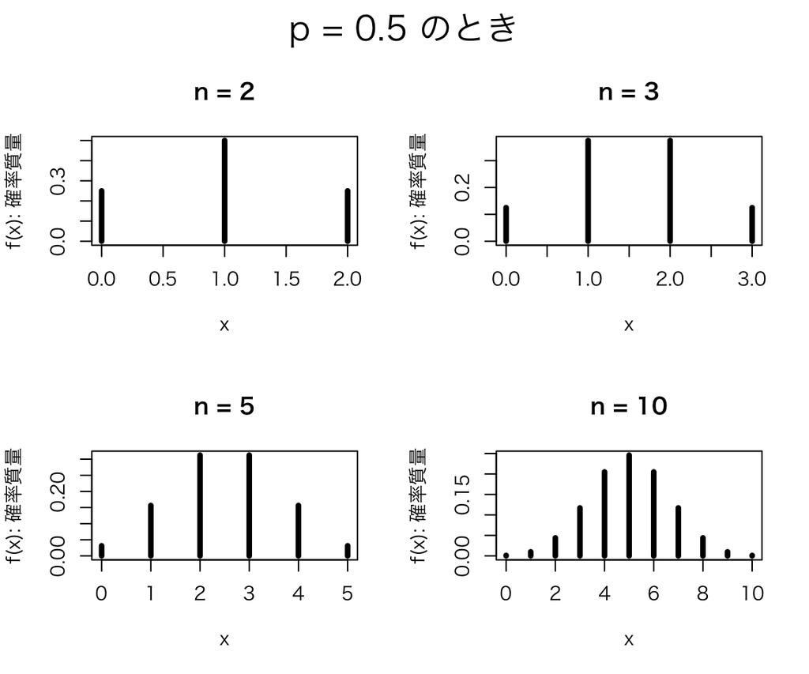

```r
par(mfrow = c(2,2), oma = c(0, 0, 2, 0))  ## 図を2行2列表示にする
for(i in 1:length(n.vec)){ # n の値ごとに図を作る
    x.vec <- 0:n.vec[i]   # xが取り得る値
    mass.vec <- rep(NA, length(x.vec))
    for(j in 1:length(x.vec)) { # xの値ごとに確率質量を求める
        mass.vec[j] <- mass.binom(x=x.vec[j], n=n.vec[i], prob=0.5)
    }
    ## 二項分布の確率分布を図示する
    ## type = "h" で棒状のグラフにする
    plot(x.vec, mass.vec, type='h', lwd=4,
         ylim=c(0, max(mass.vec)),
         xlab="x", ylab="f(x): 確率質量",
         main=paste("n =", n.vec[i]))
}
mtext("p = 0.5 のとき", outer=TRUE, cex=1.5)
```

### $p = 0.8$ のとき

$p=0.8$ の場合、上のコードの`prob` に与える値を0.8 に変えればよいが、それだけではつまらないので、少し書き方を変えてみよう。

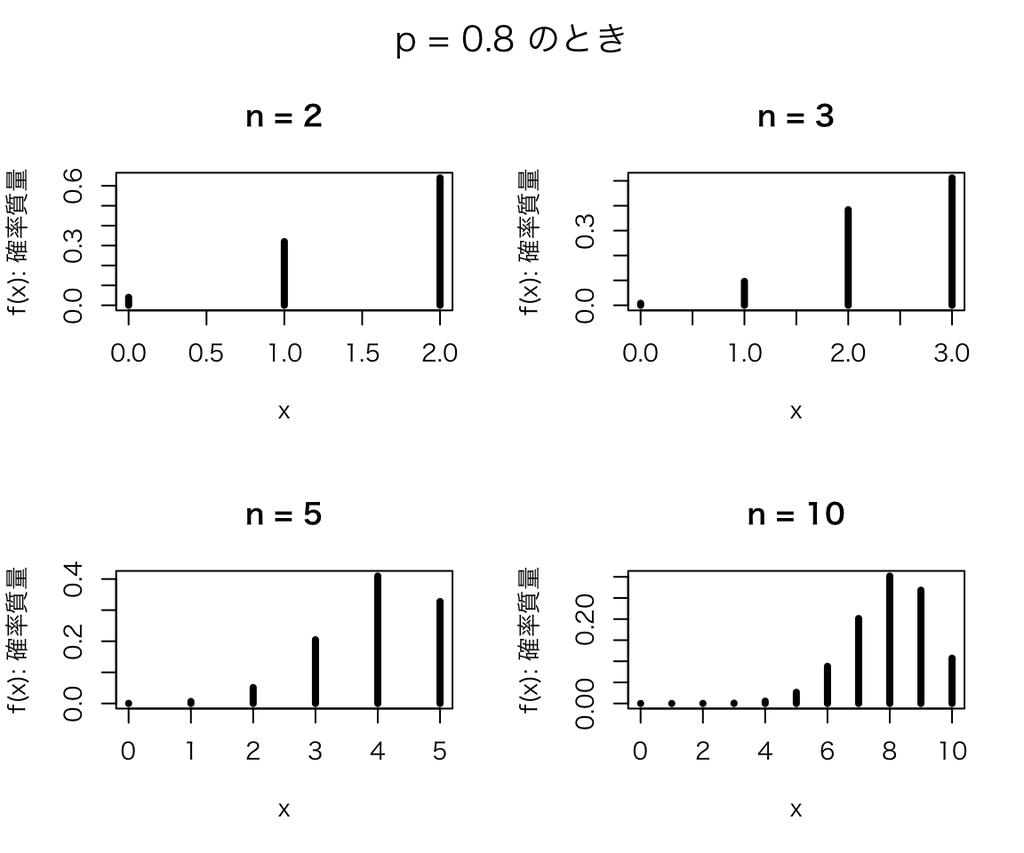

```r
par(mfrow=c(2,2), oma=c(0, 0, 2, 0))  ## 図を2行2列表示にする
for(i in 1:length(n.vec)){ # n の値ごとに図を作る
    x.vec <- 0:n.vec[i]   # xが取り得る値
    mass.vec <- mass.binom(x=x.vec, n=n.vec[i], prob=0.8)
    ## 二項分布の確率分布を図示する
    ## type = "h" を棒状のグラフにする
    plot(x.vec, mass.vec, type='h', lwd=4,
         ylim=c(0, max(mass.vec)),
         xlab="x", ylab="f(x): 確率質量",
         main=paste("n =", n.vec[i]))
}
mtext("p = 0.8 のとき", outer=TRUE, cex=1.2)
```

### ループ vs. ベクトル

上の解答例で、$p=0.5$のときは、複数の$x$に対する確率質量を求めるために、`for` ループを利用した。 しかし、$p=0.8$ のときは、`mass.vec <- mass.binom(x = x.vec, n = n.vec[i], prob = 0.8)` として、ベクトルを使った計算を実行した。

一般的に、Rではベクトルを使って処理したほうが効率がよい（計算が速い）。 今回の問題に関しては、`for` ループとベクトルの処理速度にぞれほど違いがないが、大規模なデータ処理の際には速度の違いが問題になることもあるので、可読性が著しく落ちない限り、ベクトルを利用したほうがよい。

### p = 0.1, 0.3, 0.5, 0.9 をループさせて1つの図にする

まず、それぞれの組み合わせで確率質量を求める。 ここでは、成功確率$p$を変えるための`for` ループと、ベルヌーイ試行の回数$n$を変えるための`for` ループを二重にして計算を行う。 計算結果はbinom.res という名前のデータフレームに保存する。

```r
p.vec <- c(.1, .3, .5, .9)  # 4つの成功確率を決める
## 保存するデータフレームのサイズを計算する
## (後からデータフレームを拡大するより処理が速くなる)
n.obs <- sum((n.vec + 1) * length(p.vec))
## データを保存するための空のデータフレームを作る
binom.res <- data.frame(n = rep(NA, n.obs),
                        p = rep(NA, n.obs),
                        x = rep(NA, n.obs),
                        mass = rep(NA, n.obs))
## データフレームの行を指定するためのインデクス
index <- 1
for(n in n.vec){ # 既に定義済みの4つのnを使う
    for(p in p.vec){ # 4つの成功確率pを使う
        x.vec <- 0:n  # xが取り得る値のベクトル
        # 確率質量を求める
        mass.vec <- mass.binom(x=x.vec, n=n, prob=p)
        # データフレームに保存する
        slicer <- index:(index+n)  # 保存する位置を指定する
        binom.res$n[slicer] <- n
        binom.res$p[slicer] <- p
        binom.res$x[slicer] <- x.vec
        binom.res$mass[slicer] <- mass.vec
        index <- index + n + 1    # インデクスを必要な分（n+1）だけ上げる
    }
}
```

これで、それぞれの組み合わせの確率質量が計算できた。 最後に、結果を図示しよう。 今回はggplot2 を使う。

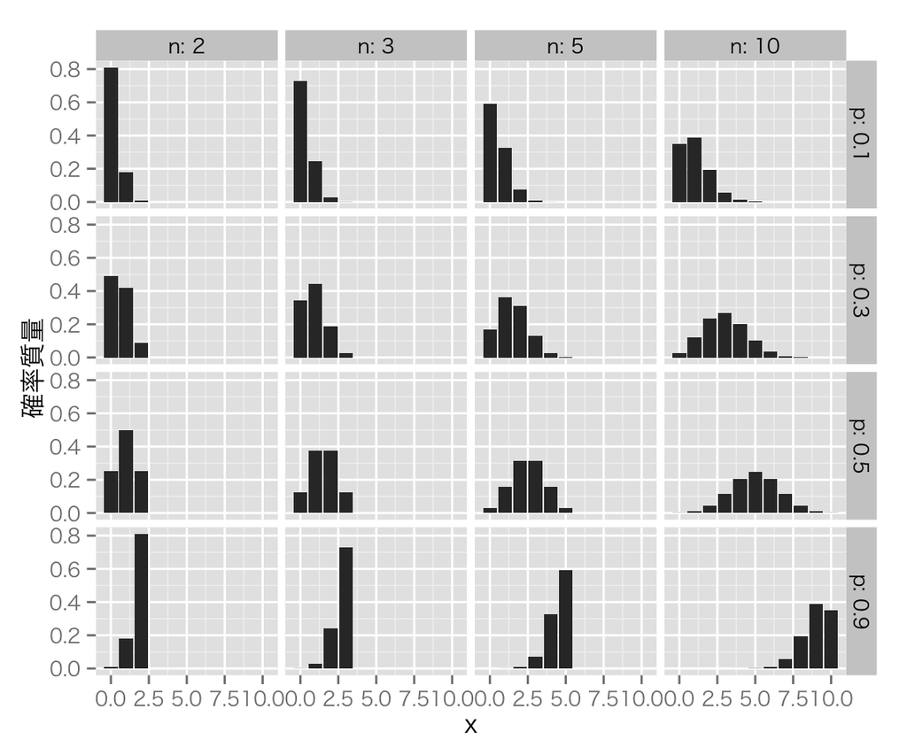

```r
require(ggplot2)
## 日本語が表示できるようにする
theme_set(theme_gray(base_size=12, base_family="HiraKakuProN-W3"))
## Windows の場合は
# theme_set(theme_gray(base_size=12, base_family="Meiryo UI"))
binom.p <- ggplot(binom.res, aes(x, mass)) + geom_bar(stat="identity")
binom.p + facet_grid(p ~ n, labeller=label_both) + ylab("確率質量")
```

授業の内容に戻る